# Ensemble_Techniques_Project_Tiffany_Chan

Tiffany Chan

Ensemble Techniques Project

Deliverable –1 (Exploratory data quality report reflecting the following)–(20)

1.Univariate analysis(12marks) a.Univariate analysis –data types and description of the independent attributes which should include (name, meaning, range of values observed, central values (mean and median), standard deviation and quartiles, analysis of the body of distributions / tails, missing values, outliers. b.Strategies to address the different data challenges such as data pollution, outlier’s treatment and missing values treatment. c.Please provide comments in jupyter notebook regarding the steps you take and insights drawn from the plots.

```python
#Importing necessary packages needed for data clearning, plotting and for creating models:
import pandas as pd
import numpy as np
from sklearn import metrics
import matplotlib.pyplot as plt
%matplotlib inline
import seaborn as sns
from sklearn.model_selection import train_test_split
from sklearn.tree import DecisionTreeClassifier
#from sklearn.feature_extraction.text import CountVectorizer
from IPython.display import Image
#import pydotplus as pydot
from sklearn import tree
from os import system
```

```python
#Reading in dataset, and renaming it "bank"
bank = pd.read_csv("bank-full.csv")
```

```python
#Printing the top 5 cases in the dataset to check we read in the dataset correctly.
print(bank.head(5))
print("")
#Dimensions of the dataset
print("Dimensions of dataset:")
print(bank.shape)
```

```
   age           job  marital  education default  balance housing loan  \
0   58    management  married   tertiary      no     2143     yes   no
1   44    technician   single  secondary      no       29     yes   no
2   33  entrepreneur  married  secondary      no        2     yes  yes
3   47   blue-collar  married    unknown      no     1506     yes   no
4   33       unknown   single    unknown      no        1      no   no

   contact  day month  duration  campaign  pdays  previous poutcome Target
0  unknown    5   may       261         1     -1         0  unknown     no
1  unknown    5   may       151         1     -1         0  unknown     no
2  unknown    5   may        76         1     -1         0  unknown     no
3  unknown    5   may        92         1     -1         0  unknown     no
4  unknown    5   may       198         1     -1         0  unknown     no

Dimensions of dataset:
(45211, 17)
```

Univariate Analysis

```python
#1a
#Data Types
print("Data Types")
print("")
print(bank.dtypes)
print("")

#Descriptive statistics of continous numerical variables before data cleaning/transformation.
print("Descriptive Statistics of continuous numerical variables.")
print("")
print(bank.describe())
print("")

#Changing string variables into categorical variables.
for feature in bank.columns: # Loop through all columns in the dataframe
    if bank[feature].dtype == 'object': # Only apply for columns with categorical strings
        bank[feature] = pd.Categorical(bank[feature])# Replace strings with an integer
#Verifying that the string variables are changed into categorical variables.
print("Modified datatypes of dataset variables")
bank.dtypes
```

```
Data Types

age           int64
job          object
marital      object
education    object
default      object
balance       int64
housing      object
loan         object
contact      object
day           int64
month        object
duration      int64
campaign      int64
pdays         int64
previous      int64
poutcome     object
Target       object
dtype: object

Descriptive Statistics of continuous numerical variables.

                age        balance           day      duration      campaign  \
count  45211.000000   45211.000000  45211.000000  45211.000000  45211.000000
mean      40.936210    1362.272058     15.806419    258.163080      2.763841
std       10.618762    3044.765829      8.322476    257.527812      3.098021
min       18.000000   -8019.000000      1.000000      0.000000      1.000000
25%       33.000000      72.000000      8.000000    103.000000      1.000000
50%       39.000000     448.000000     16.000000    180.000000      2.000000
75%       48.000000    1428.000000     21.000000    319.000000      3.000000
max       95.000000  102127.000000     31.000000   4918.000000     63.000000

              pdays      previous
count  45211.000000  45211.000000
mean      40.197828      0.580323
std      100.128746      2.303441
min       -1.000000      0.000000
25%       -1.000000      0.000000
50%       -1.000000      0.000000
75%       -1.000000      0.000000
max      871.000000    275.000000

Modified datatypes of dataset variables
```

```
age             int64
job          category
marital      category
education    category
default      category
balance         int64
housing      category
loan         category
contact      category
day             int64
month        category
duration        int64
campaign        int64
pdays           int64
previous        int64
poutcome     category
Target       category
dtype: object
```

Looking at the descriptive statistics, the pdays variable and the previous variable seem to have excessive values of -1 and 0 respectively, and may have to undergo some sort of transformation or deletion during explorative data analysis (EDA). The balance variable has -8019 as a minimum value, which most likely suggests that the account has been overdrawn, and the account owner has a negative balance. This variable may have outliers and could be something to evaluate later on when conducting univariate analysis.

```python
#Frequency of categorical variables

print("Frequency of categorical variables")
print("")
print("Dependent variable:")
print(bank['Target'].value_counts())
print("")

print("Independent categorical variables:")
print(bank['job'].value_counts())
print(bank['marital'].value_counts())
print(bank['education'].value_counts())
print(bank['default'].value_counts())
print(bank['housing'].value_counts())
print(bank['loan'].value_counts())
print(bank['contact'].value_counts())
print(bank['month'].value_counts())
print(bank['poutcome'].value_counts())
print("")

#Frequency of continuous variables of interest that are numerical and continuous in nature.
#I would like to see how many -1 and 0s there are in pdays and previous, respectively.
print("Pdays Variable Frequency")
print(bank['pdays'].value_counts())
print("Previous Variable Frequency")
print(bank['previous'].value_counts())


#Number of NAs in dataset
print("Number of missing values in dataset:")
bank.isnull().sum()
```

```
Frequency of categorical variables

Dependent variable:
no     39922
yes     5289
Name: Target, dtype: int64

Independent categorical variables:
blue-collar      9732
management       9458
technician       7597
admin.           5171
services         4154
retired          2264
self-employed    1579
entrepreneur     1487
unemployed       1303
housemaid        1240
student           938
unknown           288
Name: job, dtype: int64
married     27214
single      12790
divorced     5207
Name: marital, dtype: int64
secondary    23202
tertiary     13301
primary       6851
unknown       1857
Name: education, dtype: int64
no     44396
yes      815
Name: default, dtype: int64
yes    25130
no     20081
Name: housing, dtype: int64
no     37967
yes     7244
Name: loan, dtype: int64
cellular     29285
```

[output cut: 64 more lines]

```
30         3
28         2
26         2
37         2
38         2
55         1
40         1
35         1
58         1
51         1
41         1
32         1
275        1
Name: previous, dtype: int64
Number of missing values in dataset:
```

```
age          0
job          0
marital      0
education    0
default      0
balance      0
housing      0
loan         0
contact      0
day          0
month        0
duration     0
campaign     0
pdays        0
previous     0
poutcome     0
Target       0
dtype: int64
```

There are no NAs in the dataset. However, there are 36954 -1 values in pdays. According to the codebook of this assignment, the -1 values are either individuals that were never contacted or people who did not reciprocate after 900 days after last contact from the last campaign. So, this value could be interpreted as missing values since we do not know if they were contacted or if they did not respond purposefully after 900 days. There are also the same number of zeroes in the previous variable.

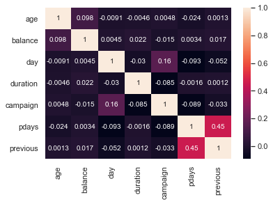

```python
#Heatmap to evaluate Pearson's correlation.
sns.heatmap(bank.corr(), annot = True);
```

Pdays and previous have a positive Pearson's correlation of 0.45, which can be interpreted as low-moderate correlation. This does not mean that we should entirely exclude either one from our models. More analysis is needed to understand what these variables look like statistically before making a decision of how to handle them.

There are two other pairings that have very low correlation: 1. day and campaign (Pearson's: 0.16), 2. balance and age (Pearson's 0.098). Day and campaign have a weak correlation, while balance and age's correlation is very close to zero and could potentially suggest no correlation at all.

The rest of the Pearson's correlation values are very small and close to zero, suggesting that the variables in these pairings may be completely independent from one another.

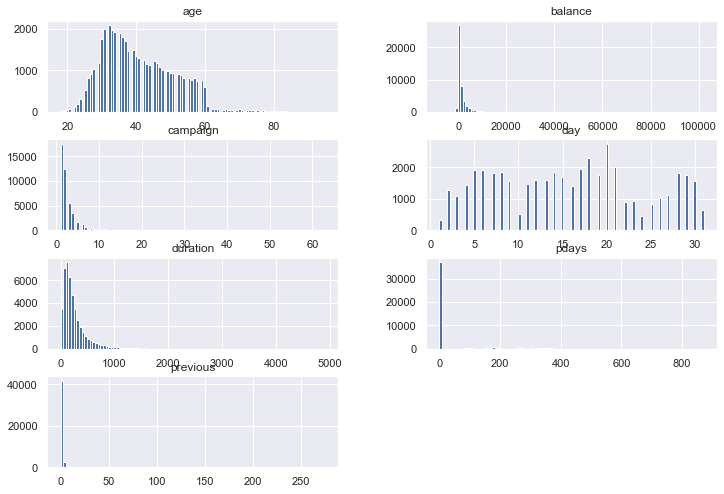

```python
#Univariate analysis
#Histograms of all the continuous variables to see the spread and shape of the data.
columns = list(bank)[:] # Creating a new list with all columns
bank[columns].hist(stacked=False, bins=100, figsize=(12,30), layout=(14,2)); # Histogram of all columns
```

From these histograms, balance, campaign, duration, pdays and previous are skewed to the right, which may suggest there could be outliers in these variables that must be handled. Age has a good spread but there may still be outliers also in this variable. In order to verify if there are true outliers, we would need to look at the range and boxplots of these variables.

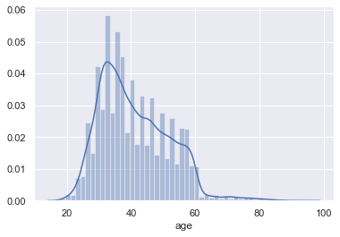

```python
#A better look at the histogram for age.
#It does not follow a normal distribution.

sns.distplot(bank['age'])
```

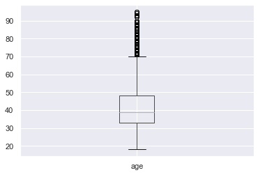

```python
#Boxplot for age to see if there are outliers beyond the whiskers.

bank[['age']].boxplot()
```

There are outliers for age, and there are multiple ways of dealing with outliers. In general, a good way to deal with a variable like age that has to make predictions on a categorical dependent variable, is to categorize it into different age groups.

```python
bins = [18, 30, 40, 50, 60, 70, 80, 90, 100]
labels = ['18-29', '30-39', '40-49', '50-59', '60-69', '70-79', '80-89', '90-99']
bank['agerange'] = pd.cut(bank.age, bins, labels = labels,include_lowest = True)
bank['agerange'] = bank.agerange.astype(str)
```

```python
bank.dtypes  #agerange is the categorical variable for age, but it is listed below as a string. I will change this later down below with One Hot Encoding.
```

```
age             int64
job          category
marital      category
education    category
default      category
balance         int64
housing      category
loan         category
contact      category
day             int64
month        category
duration        int64
campaign        int64
pdays           int64
previous        int64
poutcome     category
Target       category
agerange       object
dtype: object
```

### There are many variables in this dataset that have outliers. Outliers can be defined as any points that go beyond the boxplot whiskers. There are outliers that like beyond 3*IQR and then there are suspected outliers that lie beyond 1.5* IQR.

### For these values, we will have to do many imputations for measures beyond the boxplot whiskers.

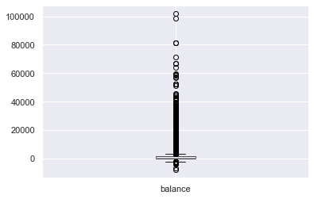

```python
# Balance boxplot to see the outliers.
bank[['balance']].boxplot()
```

```python
#Calculate the whisker values of the boxplot to get the threshold that separates the outliers.
#Calculate the interquartile range:
q75, q25 = np.percentile(bank['balance'], [75 ,25])
iqr = q75 - q25

#Interquartile range:
print("Interquartile range:")
print(iqr)
print("75th percentile")
print(q75)
print("25th percentile")
print(q25)
print("Upper whisker")
print(q75 + 1.5*iqr)
print("Lower whisker")
print(q25 - 1.5*iqr)
```

```
Interquartile range:
1356.0
75th percentile
1428.0
25th percentile
72.0
Upper whisker
3462.0
Lower whisker
-1962.0
```

```python
#Looking at how much of the variable points are outliers

balanceoutlier_max = bank[(bank['balance'] > 3462)]
print(balanceoutlier_max)   #10.4% of the data variable
balanceoutlier_min = bank[(bank['balance'] < -1962)]
balanceoutlier_min  #0.037% of the data variable
```

```
       age          job   marital  education default  balance housing loan  \
34      51   management   married   tertiary      no    10635     yes   no
65      51   management   married   tertiary      no     6530     yes   no
69      35  blue-collar    single  secondary      no    12223     yes  yes
70      57  blue-collar   married  secondary      no     5935     yes  yes
186     40     services  divorced    unknown      no     4384     yes   no
...    ...          ...       ...        ...     ...      ...     ...  ...
45164   35     services   married   tertiary      no     4655      no   no
45181   46  blue-collar   married  secondary      no     6879      no   no
45185   60     services   married   tertiary      no     4256     yes   no
45191   75      retired  divorced   tertiary      no     3810     yes   no
45208   72      retired   married  secondary      no     5715      no   no

        contact  day month  duration  campaign  pdays  previous poutcome  \
34      unknown    5   may       336         1     -1         0  unknown
```

[output cut: 25 more lines]

|  | age | job | marital | education | default | balance | housing | loan | contact | day | month | duration | campaign | pdays | previous | poutcome | Target | agerange |
| --- | --- | --- | --- | --- | --- | --- | --- | --- | --- | --- | --- | --- | --- | --- | --- | --- | --- | --- |
| 1896 | 57 | self-employed | married | tertiary | yes | -3313 | yes | yes | unknown | 9 | may | 153 | 1 | -1 | 0 | unknown | no | 50-59 |
| 7413 | 43 | management | married | tertiary | yes | -3372 | yes | no | unknown | 29 | may | 386 | 2 | -1 | 0 | unknown | no | 40-49 |
| 7756 | 49 | management | divorced | tertiary | no | -2049 | yes | no | unknown | 30 | may | 169 | 3 | -1 | 0 | unknown | no | 40-49 |
| 11655 | 56 | management | divorced | tertiary | yes | -1968 | no | no | unknown | 20 | jun | 60 | 3 | -1 | 0 | unknown | no | 50-59 |
| 12909 | 26 | blue-collar | single | secondary | yes | -8019 | no | yes | cellular | 7 | jul | 299 | 3 | -1 | 0 | unknown | no | 18-29 |
| 13687 | 38 | blue-collar | divorced | secondary | no | -2093 | yes | yes | unknown | 9 | jul | 120 | 3 | -1 | 0 | unknown | no | 30-39 |
| 13708 | 49 | entrepreneur | married | secondary | no | -1965 | no | yes | telephone | 10 | jul | 317 | 2 | -1 | 0 | unknown | no | 40-49 |
| 14434 | 51 | management | divorced | tertiary | no | -2282 | yes | yes | cellular | 14 | jul | 301 | 6 | -1 | 0 | unknown | no | 50-59 |
| 15682 | 49 | management | married | tertiary | yes | -6847 | no | yes | cellular | 21 | jul | 206 | 1 | -1 | 0 | unknown | no | 40-49 |
| 17159 | 51 | entrepreneur | married | secondary | yes | -2082 | no | yes | cellular | 28 | jul | 123 | 6 | -1 | 0 | unknown | no | 50-59 |
| 18573 | 40 | technician | married | tertiary | yes | -2827 | yes | yes | cellular | 31 | jul | 843 | 1 | -1 | 0 | unknown | no | 30-39 |
| 20317 | 35 | management | single | tertiary | yes | -1980 | yes | yes | cellular | 11 | aug | 227 | 1 | -1 | 0 | unknown | no | 30-39 |
| 25119 | 49 | blue-collar | single | primary | yes | -2604 | yes | no | cellular | 18 | nov | 142 | 1 | -1 | 0 | unknown | no | 40-49 |
| 25240 | 43 | services | married | primary | no | -2122 | yes | yes | cellular | 18 | nov | 141 | 3 | -1 | 0 | unknown | no | 40-49 |
| 31509 | 52 | management | married | tertiary | no | -2712 | yes | yes | cellular | 2 | apr | 253 | 1 | -1 | 0 | unknown | no | 50-59 |
| 32713 | 39 | self-employed | married | tertiary | no | -3058 | yes | yes | cellular | 17 | apr | 882 | 3 | -1 | 0 | unknown | yes | 30-39 |
| 38736 | 60 | management | divorced | tertiary | no | -4057 | yes | no | cellular | 18 | may | 242 | 6 | -1 | 0 | unknown | no | 50-59 |

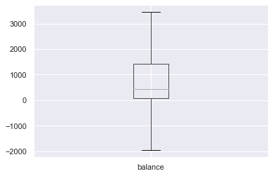

```python
#Replace the outliers with the value of the whiskers. This is one technique to handle the outliers of skewed data.
#Making new boxplot to check if outliers are replaced. Run this code twice to make sure the imputations are met.
bank.balance[bank['balance']>3462] = 3462
bank[['balance']].boxplot()
bank.balance[bank['balance']<-1962] = -1962
bank[['balance']].boxplot()
```

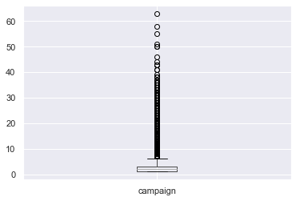

```python
#Boxplot for campaign variable.

bank[['campaign']].boxplot();
```

There are only right skewed outliers in this variable.

```python
#Calculate the whisker values of the boxplot to get the threshold that separates the outliers.
#Calculate the interquartile range:
q75, q25 = np.percentile(bank['campaign'], [75 ,25])
iqr = q75 - q25

#Interquartile range:
print("Interquartile range:")
print(iqr)
print("75th percentile")
print(q75)
print("25th percentile")
print(q25)
print("Upper whisker")
print(q75 + 1.5*iqr)
print("Lower whisker")
print(q25 - 1.5*iqr)
```

```
Interquartile range:
2.0
75th percentile
3.0
25th percentile
1.0
Upper whisker
6.0
Lower whisker
-2.0
```

```python
#Set the threshold to the upper whisker. Find out how many outliers are in this variable.

campaignoutlier_max = bank[(bank['campaign'] > 6)]
print(campaignoutlier_max)   #6.8% of the data
```

```
       age            job  marital  education default  balance housing loan  \
758     59       services  married  secondary      no      307     yes  yes
780     30         admin.  married  secondary      no        4      no   no
906     27       services   single  secondary      no        0     yes   no
1103    52     technician  married    unknown      no      133     yes   no
1105    43         admin.  married   tertiary      no     1924     yes   no
...    ...            ...      ...        ...     ...      ...     ...  ...
44666   25     technician   single  secondary      no     1298      no   no
44680   27  self-employed   single   tertiary      no      560      no   no
44770   37       services   single   tertiary      no     1189      no   no
44886   38     management  married   tertiary      no        0      no   no
45056   64     management  married   tertiary      no     3462      no   no

         contact  day month  duration  campaign  pdays  previous poutcome  \
758      unknown    6   may       250         7     -1         0  unknown
```

[output cut: 25 more lines]

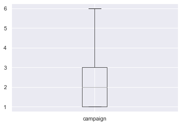

```python
#Set the outliers to the upper whisker value and verify.

bank.campaign[bank['campaign']>6] = 6
bank[['campaign']].boxplot()
```

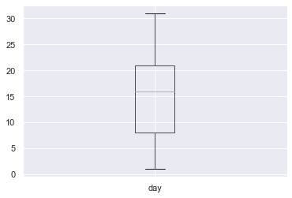

```python
#Boxplot for day variable.

bank[['day']].boxplot()
```

There are no outliers in the day variable. So, there is no need to transform the data.

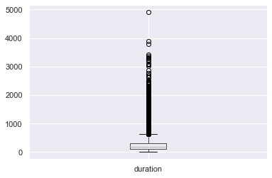

```python
#Boxplot for duration.

bank[['duration']].boxplot()
```

There are only outliers above the upper whisker.

```python
#Calculate the whisker values of the boxplot to get the threshold that separates the outliers.
#Calculate the interquartile range:
q75, q25 = np.percentile(bank['duration'], [75 ,25])
iqr = q75 - q25

#Interquartile range:
print("Interquartile range:")
print(iqr)
print("75th percentile")
print(q75)
print("25th percentile")
print(q25)
print("Upper whisker")
print(q75 + 1.5*iqr)
print("Lower whisker")
print(q25 - 1.5*iqr)
```

```
Interquartile range:
216.0
75th percentile
319.0
25th percentile
103.0
Upper whisker
643.0
Lower whisker
-221.0
```

```python
durationoutlier_max = bank[(bank['duration'] > 643)]
print(durationoutlier_max)   #7.2% of the data variable
```

```
       age          job   marital  education default  balance housing loan  \
37      53   technician   married  secondary      no       -3      no   no
43      54      retired   married  secondary      no      529     yes   no
53      42       admin.    single  secondary      no      -76     yes   no
59      46     services   married    primary      no      179     yes   no
61      53   technician  divorced  secondary      no      989     yes   no
...    ...          ...       ...        ...     ...      ...     ...  ...
45124   27  blue-collar    single    primary      no      232     yes   no
45199   34  blue-collar    single  secondary      no     1475     yes   no
45200   38   technician   married  secondary      no      557     yes   no
45206   51   technician   married   tertiary      no      825      no   no
45208   72      retired   married  secondary      no     3462      no   no

        contact  day month  duration  campaign  pdays  previous poutcome  \
37      unknown    5   may      1666         1     -1         0  unknown
```

[output cut: 25 more lines]

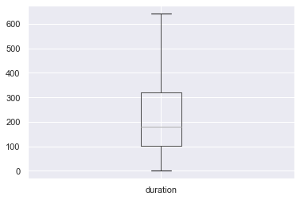

```python
#Replacing the outliers with the value of the upper whisker.

bank.duration[bank['duration']>643] = 643
bank[['duration']].boxplot()
```

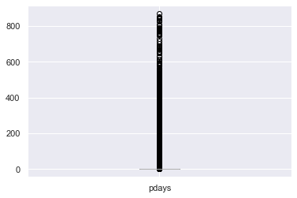

```python
#Boxplot for pdays.

bank[['pdays']].boxplot()
```

```python
#Calculate the whisker values of the boxplot to get the threshold that separates the outliers.
#Calculate the interquartile range:
q75, q25 = np.percentile(bank['pdays'], [75 ,25])
iqr = q75 - q25

#Interquartile range:
print("Interquartile range:")
print(iqr)
print("75th percentile")
print(q75)
print("25th percentile")
print(q25)
print("Upper whisker")
print(q75 + 1.5*iqr)
print("Lower whisker")
print(q25 - 1.5*iqr)
```

```
Interquartile range:
0.0
75th percentile
-1.0
25th percentile
-1.0
Upper whisker
-1.0
Lower whisker
-1.0
```

The upper whisker is the -1 value(which can be interpreted as an unknown value because we don't know if they were contacted or they never responded after 900 days). Replacing the outliers with this value would not serve much benefit because it would just create more -1 values or unknowns in the data. It would just make sense to discard this column all together.

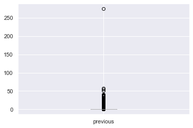

```python
bank[['previous']].boxplot()
```

```python
#Calculate the whisker values of the boxplot to get the threshold that separates the outliers.
#Calculate the interquartile range:
q75, q25 = np.percentile(bank['previous'], [75 ,25])
iqr = q75 - q25

#Interquartile range:
print("Interquartile range:")
print(iqr)
print("75th percentile")
print(q75)
print("25th percentile")
print(q25)
print("Upper whisker")
print(q75 + 1.5*iqr)
print("Lower whisker")
print(q25 - 1.5*iqr)
```

```
Interquartile range:
0.0
75th percentile
0.0
25th percentile
0.0
Upper whisker
0.0
Lower whisker
0.0
```

It would also just make sense to discard this column because there are too many zeroes.

1b. The variables of concern seem to be pdays and poutcome.

For pdays, the number of -1 in the variable is concerning because -1 means either the customer was not contacted or that more than 900 days have passed by since the last contact. These two conditions have completely different meanings and should be reported as missing values. There is not enough information from the other dataset variables or the codebook to differentiate the two groups. "-1" appears in total 36954 times in the pdays variable, which is approximately 81.7% of the dataset. Due to the excessive number of missing values, it would be more beneficial to lose this column all together, since more than half have missing values (Kumar, 2020). This way, you maintain a more robust robust model than if mean/median/mode or confidence level imputations are done for 81.7% of this variable. The downside of this method would be the loss of data. However, only about 18.3% of the variable data would be sacrificed, which is not too much. The same is applied to the previous variable.

### BIVARIATE ANALYSIS:

### 2.Multivariate analysis(8marks)

### a.Bi-variate analysis between the predictor variables and target column. Comment on your findings in terms of their relationship and degree of relation if any. Visualize the analysis using boxplots and pair plots, histograms or density curves. Select the most appropriate attributes.

### b.Please provide comments in jupyter notebook regarding the steps you take and insights drawn from the plots

## Bivariate analysis for continuous predictors and target variable.

```
AxesSubplot(0.125,0.125;0.775x0.755)
```

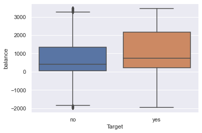

```python
#Boxplot for balance x target

print(sns.boxplot(x = 'Target', y = 'balance', data = bank));
```

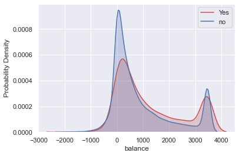

```python
#Density curves for balance x target

balancekde= sns.kdeplot(bank.loc[(bank['Target']=='yes'),
            'balance'], color='r', shade=True, Label='Yes')

balancekde= sns.kdeplot(bank.loc[(bank['Target']=='no'),
            'balance'], color='b', shade=True, Label='no');
balancekde.set(xlabel="balance", ylabel = "Probability Density");
```

There are similar trends between balance and the target variable. There are spikes in the data for both yes and no for term deposit. The reason may be that there are more individuals sampled that have balances closely below and above 0, as well as individuals that have $3000-4000 balance.

```
AxesSubplot(0.125,0.125;0.775x0.755)
```

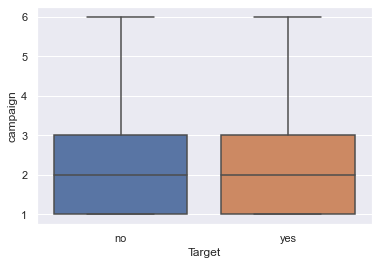

```python
#Boxplot for campaign
print(sns.boxplot(x = 'Target', y = 'campaign', data = bank));
```

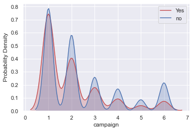

```python
#Density plot for campaign

campaignkde= sns.kdeplot(bank.loc[(bank['Target']=='yes'),
            'campaign'], color='r', shade=True, Label='Yes')

campaignkde= sns.kdeplot(bank.loc[(bank['Target']=='no'),
            'campaign'], color='b', shade=True, Label='no')

campaignkde.set(xlabel="campaign", ylabel = "Probability Density");
```

The bank made the most one calls to clients. The median campaign contacts for those who did and did not subscribe to term deposit was roughly 2 for both groups according to the boxplot.

```
AxesSubplot(0.125,0.125;0.775x0.755)
```

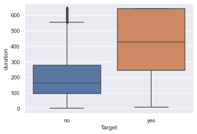

```python
#Duration- This is not a variable that will be used in the models later because the variable highly affects output target and should be discarded according to the data source.
#Boxplot for duration.
print(sns.boxplot(x = 'Target', y = 'duration', data = bank));
```

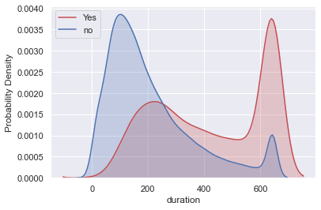

```python
#Density graphs for duration.
durationkde= sns.kdeplot(bank.loc[(bank['Target']=='yes'),
            'duration'], color='r', shade=True, Label='Yes')

durationkde= sns.kdeplot(bank.loc[(bank['Target']=='no'),
            'duration'], color='b', shade=True, Label='no')

durationkde.set(xlabel="duration", ylabel = "Probability Density");
```

# The density plot makes sense because the more time spent on the call, the higher the probability density the individual will sign up for a term deposit. The less amount of time spent on the phone would suggest disinterest and more likely not lead to signing up for a term deposit.

```
AxesSubplot(0.125,0.125;0.775x0.755)
```

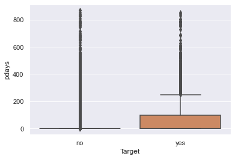

```python
print(sns.boxplot(x = 'Target', y = 'pdays', data = bank));
```

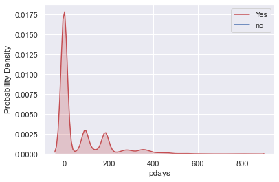

```python
pdayskde= sns.kdeplot(bank.loc[(bank['Target']=='yes'),
            'pdays'], color='r', shade=True, Label='Yes')

pdayskde= sns.kdeplot(bank.loc[(bank['Target']=='no'),
            'pdays'], color='b', shade=True, Label='no')

pdayskde.set(xlabel="pdays", ylabel = "Probability Density");
```

As discussed before, this variable will not be included in the model, as this right skewed data only represents approximately 18.3% of the data in this variable. Many of these values on the skewed tail are considered outliers.

```
AxesSubplot(0.125,0.125;0.775x0.755)
```

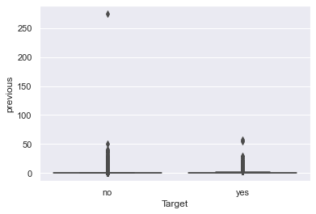

```python
print(sns.boxplot(x = 'Target', y = 'previous', data = bank));
```

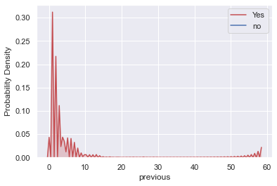

```python
#Density plot for previous x target
previouskde= sns.kdeplot(bank.loc[(bank['Target']=='yes'),
            'previous'], color='r', shade=True, Label='Yes')

previouskde= sns.kdeplot(bank.loc[(bank['Target']=='no'),
            'previous'], color='b', shade=True, Label='no')

previouskde.set(xlabel="previous", ylabel = "Probability Density");
```

For the same reason as stated above and what was stated for pdays. Imputing this variable's outliers on the skewed table would generate more 0s. Discarding this variable would generate more robust models.

```
AxesSubplot(0.125,0.125;0.775x0.755)
```

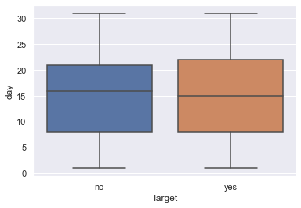

```python
#Days x Target
print(sns.boxplot(x = 'Target', y = 'day', data = bank));
```

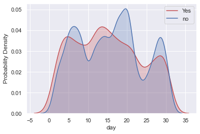

```python
#Density plot for day x target
previouskde= sns.kdeplot(bank.loc[(bank['Target']=='yes'),
            'day'], color='r', shade=True, Label='Yes')

previouskde= sns.kdeplot(bank.loc[(bank['Target']=='no'),
            'day'], color='b', shade=True, Label='no')

previouskde.set(xlabel="day", ylabel = "Probability Density");
```

There seems to be more positve response from 0 to short of 15 days. 15 days and onwards seems to generate less positive outcomes in terms of term deposit sign ups.

### Bivariate analysis for categorical independent variables

```
Target        no   yes
education
primary     6260   591
secondary  20752  2450
tertiary   11305  1996
unknown     1605   252
AxesSubplot(0.125,0.125;0.775x0.755)
```

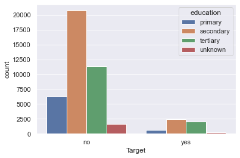

```python
# Education x Target

#Frequency using 3x2 table and then plotting bar graph to illustrate this frequency.
print(pd.crosstab(bank['education'],bank['Target']))
ax = sns.countplot(x="Target", hue="education", data=bank)
print(ax)
```

```python
#Crosstabs to evaluate the relationship between the two variables.
print(pd.crosstab(bank['education'],bank['Target'],normalize='columns'))
```

```
Target           no       yes
education
primary    0.156806  0.111741
secondary  0.519814  0.463226
tertiary   0.283177  0.377387
unknown    0.040203  0.047646
```

Those who have tertiary education subscribe more to term deposits compared to those who have a primary education.

```
Target           no   yes
job
admin.         4540   631
blue-collar    9024   708
entrepreneur   1364   123
housemaid      1131   109
management     8157  1301
retired        1748   516
self-employed  1392   187
services       3785   369
student         669   269
technician     6757   840
unemployed     1101   202
unknown         254    34
```

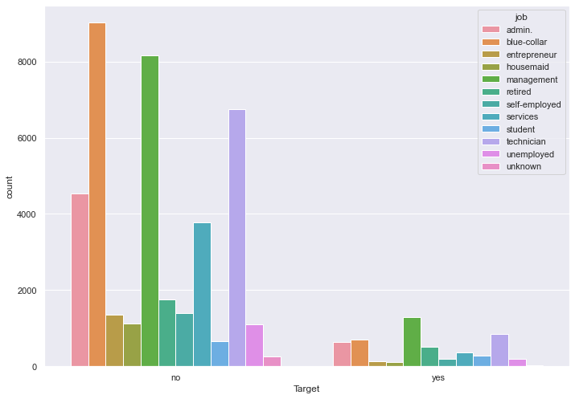

```python
#Job x Target
#Table to evaluate frequency values for job x target, and plotting these results.

print(pd.crosstab(bank['job'],bank['Target']))
sns.set(rc={'figure.figsize':(11.7,8.27)})
bx = sns.countplot(x="Target", hue="job", data=bank)
bx;
```

```python
#Crosstabs to evaluate the relationship between both variables (job x target)
print(pd.crosstab(bank['job'],bank['Target'],normalize='columns'))
```

```
Target               no       yes
job
admin.         0.113722  0.119304
blue-collar    0.226041  0.133863
entrepreneur   0.034167  0.023256
housemaid      0.028330  0.020609
management     0.204323  0.245982
retired        0.043785  0.097561
self-employed  0.034868  0.035356
services       0.094810  0.069767
student        0.016758  0.050860
technician     0.169255  0.158820
unemployed     0.027579  0.038192
unknown        0.006362  0.006428
```

Those with blue collar jobs are less likely to get a term deposit compared to other occupations. People who are self-employed seem to display the same distribution when it comes to subscribing to a term deposit or not subscribing to a term deposit. The same trend is observed among those with unknown jobs, technicians, and administrators. However, those that are retired and students are more likely to get a term deposit than not.

```
Target       no   yes
marital
divorced   4585   622
married   24459  2755
single    10878  1912
```

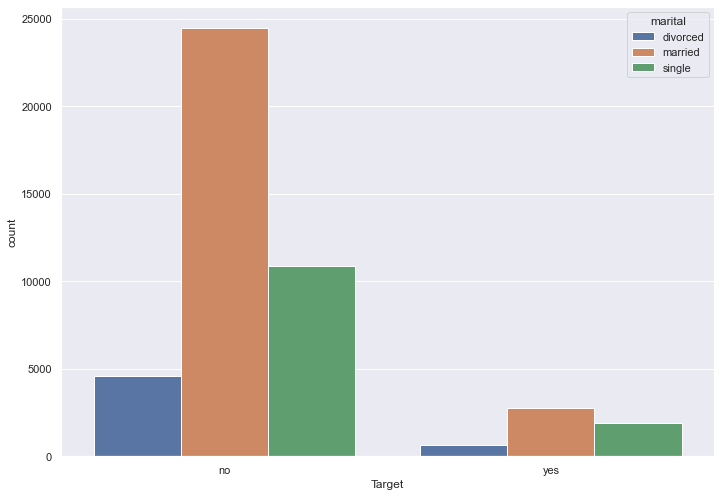

```python
#Marital x Target
#2x2 to observe the frequency of marital status by target status, and accompanying bar plot.
print(pd.crosstab(bank['marital'],bank['Target']))

cx = sns.countplot(x="Target", hue="marital", data=bank)
cx;
```

```python
#Crosstabs to evaluate the relationship between both variables (marital x target)
print(pd.crosstab(bank['marital'],bank['Target'],normalize='columns'))
```

```
Target          no       yes
marital
divorced  0.114849  0.117603
married   0.612670  0.520892
single    0.272481  0.361505
```

Those that are married are less likely to subscribe to a term deposit than those that are single. The distribution is the same among those that are divorced when it comes to subscribing or not subscribing to a term deposit.

```
Target      no   yes
default
no       39159  5237
yes        763    52
```

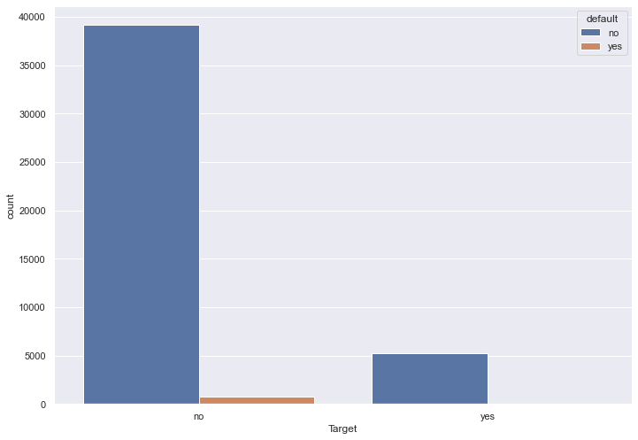

```python
#Default x Target
#Frequency of target status by default status using 2x2 table and plot.

print(pd.crosstab(bank['default'],bank['Target']))
dx = sns.countplot(x="Target", hue="default", data=bank)
dx;
```

```python
#Crosstabs to evaluate the relationship between both variables (default x target)
print(pd.crosstab(bank['default'],bank['Target'],normalize='columns'))
```

```
Target         no       yes
default
no       0.980888  0.990168
yes      0.019112  0.009832
```

Those that did not default have the same distribution when it comes to subscribing or not subscribing to term deposit. Those that did default are less likely to take a term deposit.

```
Target      no   yes
housing
no       16727  3354
yes      23195  1935
```

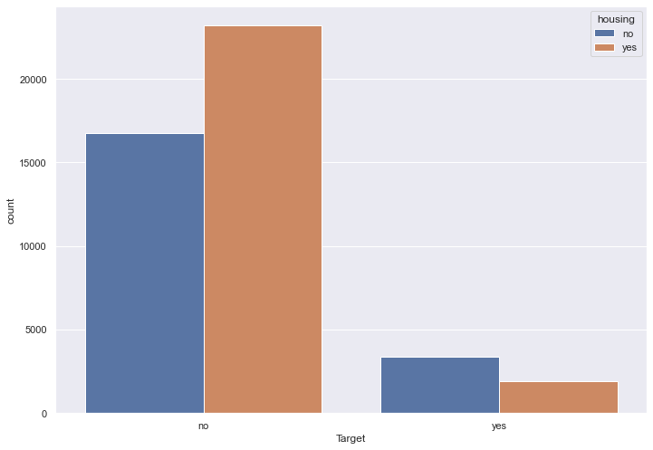

```python
#Housing x Target
#2x2 table showing the frequency of housing by target, and accompanying bar chart.

print(pd.crosstab(bank['housing'],bank['Target']))
ex = sns.countplot(x="Target", hue="housing", data=bank)
ex;
```

```python
#Crosstabs to evaluate the relationship between both variables (housing x target)
print(pd.crosstab(bank['housing'],bank['Target'],normalize='columns'))
```

```
Target         no       yes
housing
no       0.418992  0.634146
yes      0.581008  0.365854
```

Those that have a housing loan are less likely to engage to a term deposit. Those that don't have housing loans are more likely to subscribe to a term deposit.

```
Target     no   yes
loan
no      33162  4805
yes      6760   484
```

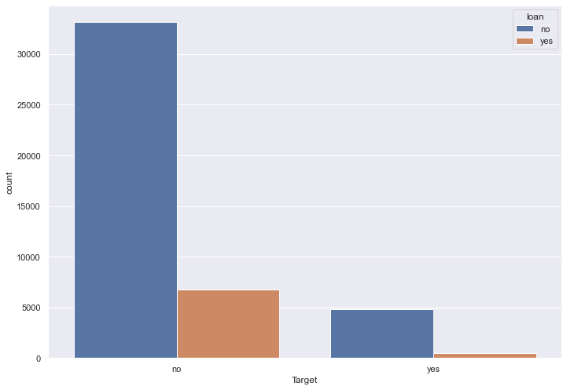

```python
#Loan x Target
#2x2 table showing target frequencies by loan and accompanying bar chart.

print(pd.crosstab(bank['loan'],bank['Target']))
fx = sns.countplot(x="Target", hue="loan", data=bank)
fx;
```

```python
#Crosstabs to evaluate the relationship between both variables (loan x target)
print(pd.crosstab(bank['loan'],bank['Target'],normalize='columns'))
```

```
Target       no       yes
loan
no      0.83067  0.908489
yes     0.16933  0.091511
```

Those that have a personal loan are less likely to get a term deposit. Those that don't have a personal loan are slightly more likely to get a term deposit.

```
Target        no   yes
contact
cellular   24916  4369
telephone   2516   390
unknown    12490   530
```

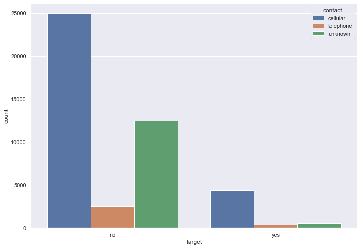

```python
#Contact x Target
#2x2 table showing frequencies of target by contact means, and bar chart.

print(pd.crosstab(bank['contact'],bank['Target']))
gx = sns.countplot(x="Target", hue="contact", data=bank)
gx;
```

```python
#Crosstabs to evaluate the relationship between both variables (contact x target)
print(pd.crosstab(bank['contact'],bank['Target'],normalize='columns'))
```

```
Target           no       yes
contact
cellular   0.624117  0.826054
telephone  0.063023  0.073738
unknown    0.312860  0.100208
```

Those that were using their cells were more likely to agree to a term deposit. Those that use a telephone are more likely to subscribe to a term deposit. Those with unknown contact means were more likely to not subscribe to a term deposit.

```
Target     no  yes
month
apr      2355  577
aug      5559  688
dec       114  100
feb      2208  441
jan      1261  142
jul      6268  627
jun      4795  546
mar       229  248
may     12841  925
nov      3567  403
oct       415  323
sep       310  269
```

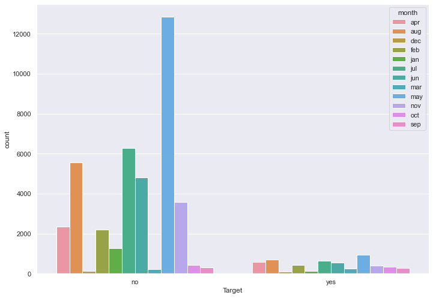

```python
#Month x Target
#Frequency table of Target by Month, and bar plot.

print(pd.crosstab(bank['month'],bank['Target']))
sns.set(rc={'figure.figsize':(11.7,8.27)})
hx = sns.countplot(x="Target", hue="month", data=bank)
hx;
```

```python
#Crosstabs to evaluate the relationship between both variables (month x target)
print(pd.crosstab(bank['month'],bank['Target'],normalize='columns'))
```

```
Target        no       yes
month
apr     0.058990  0.109094
aug     0.139247  0.130081
dec     0.002856  0.018907
feb     0.055308  0.083381
jan     0.031587  0.026848
jul     0.157006  0.118548
jun     0.120109  0.103233
mar     0.005736  0.046890
may     0.321652  0.174891
nov     0.089349  0.076196
oct     0.010395  0.061070
sep     0.007765  0.050860
```

Those that were last contacted in February, March, April, September, October and December are more likely to say yes to a term deposit. Last contact in January, May, June, July, and November were less likely to say yes to a term deposit. The reamaining months exhibited no difference between accepting or refusing a term deposit.

```
Target       no   yes
poutcome
failure    4283   618
other      1533   307
success     533   978
unknown   33573  3386
```

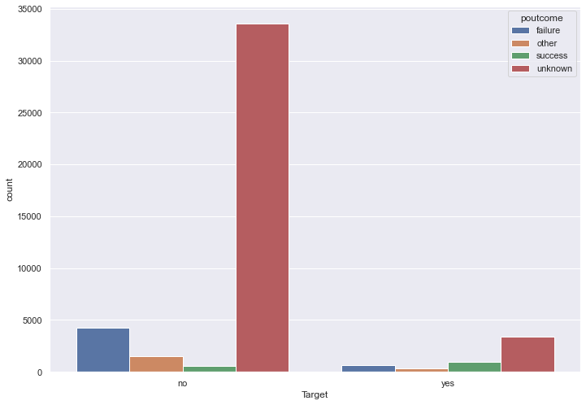

```python
#Frequency table of target variable by poutcome and bar chart.

print(pd.crosstab(bank['poutcome'],bank['Target']))
ix = sns.countplot(x="Target", hue="poutcome", data=bank)
ix;
```

```python
#Crosstabs to evaluate the relationship between both variables (poutcome x target)
print(pd.crosstab(bank['poutcome'],bank['Target'],normalize='columns'))
```

```
Target          no       yes
poutcome
failure   0.107284  0.116846
other     0.038400  0.058045
success   0.013351  0.184912
unknown   0.840965  0.640197
```

Those that had a positive outcome from the last campaign are more likely to subscribe to a term deposit, while those whose outcomes were unknown for the last campaign are more likely to not subscribe to a term deposit. Those who had a negative outcome did not show much of a difference in subscribing and not subscribing to a term deposit.

```
Target       no   yes
agerange
18-29      5885  1145
30-39     15875  1812
40-49     10220  1019
50-59      7256   811
60-69       417   284
70-79       213   175
80-89        54    38
90-99         2     5
```

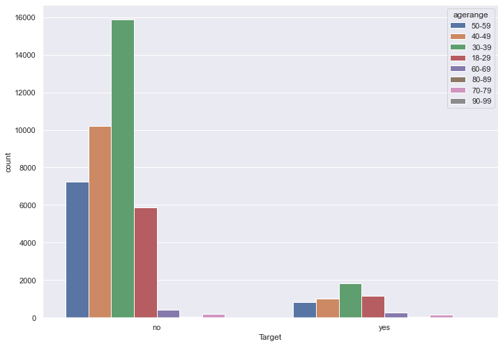

```python
#Agerange x Target
#Agerange is a categorical variable that was derived from age.
#Frequency of agerange by target variable, and bar chart.

print(pd.crosstab(bank['agerange'],bank['Target']))
jx = sns.countplot(x="Target", hue="agerange", data=bank)
jx;
```

```python
#Crosstabs to evaluate the relationship between both variables (agerange x target)
print(pd.crosstab(bank['agerange'],bank['Target'],normalize='columns'))
```

```
Target          no       yes
agerange
18-29     0.147412  0.216487
30-39     0.397650  0.342598
40-49     0.255999  0.192664
50-59     0.181754  0.153337
60-69     0.010445  0.053696
70-79     0.005335  0.033088
80-89     0.001353  0.007185
90-99     0.000050  0.000945
```

Those between the ages of 30-59 are less likely to subscribe to a term deposit. Those that are younger(18-29) and those about to retire and retirees are more likely to participate in getting a term deposit.

## Deliverable –2 (Prepare the data for analytics)–(10)

### 1.Ensure the attribute types are correct. If not, take appropriate actions.

### 2.Get the data model ready.

### 3.Transform the data i.e. scale / normalize if required

### 4.Create the training set and test set in ratio of 70:30

```python
#Evaluating every variable's dtype.

bank.dtypes
```

```
age             int64
job          category
marital      category
education    category
default      category
balance         int64
housing      category
loan         category
contact      category
day             int64
month        category
duration        int64
campaign        int64
pdays           int64
previous        int64
poutcome     category
Target       category
agerange       object
dtype: object
```

```python
#Replacing string categories with numerical values. Making these variables numerical.

replaceStruct = {
                "default":  {"no": 0, "yes": 1 },
                "housing": {"no": 0, "yes":1 },
                "loan": {"no": 0, "yes":1 },
                "Target":     {"no": 0, "yes": 1 }
                    }

#One hot encoding variables with multiple categories.
oneHotCols=["job","marital","education","contact","month","poutcome","agerange"]
```

```python
#Applying the above to the dataset.
#Create dummy variables for model.
bank=bank.replace(replaceStruct)
bank=pd.get_dummies(bank, columns=oneHotCols)
bank.head(10)
```

|  | age | default | balance | housing | loan | day | duration | campaign | pdays | previous | ... | poutcome_success | poutcome_unknown | agerange_18-29 | agerange_30-39 | agerange_40-49 | agerange_50-59 | agerange_60-69 | agerange_70-79 | agerange_80-89 | agerange_90-99 |
| --- | --- | --- | --- | --- | --- | --- | --- | --- | --- | --- | --- | --- | --- | --- | --- | --- | --- | --- | --- | --- | --- |
| 0 | 58 | 0 | 2143 | 1 | 0 | 5 | 261 | 1 | -1 | 0 | ... | 0 | 1 | 0 | 0 | 0 | 1 | 0 | 0 | 0 | 0 |
| 1 | 44 | 0 | 29 | 1 | 0 | 5 | 151 | 1 | -1 | 0 | ... | 0 | 1 | 0 | 0 | 1 | 0 | 0 | 0 | 0 | 0 |
| 2 | 33 | 0 | 2 | 1 | 1 | 5 | 76 | 1 | -1 | 0 | ... | 0 | 1 | 0 | 1 | 0 | 0 | 0 | 0 | 0 | 0 |
| 3 | 47 | 0 | 1506 | 1 | 0 | 5 | 92 | 1 | -1 | 0 | ... | 0 | 1 | 0 | 0 | 1 | 0 | 0 | 0 | 0 | 0 |
| 4 | 33 | 0 | 1 | 0 | 0 | 5 | 198 | 1 | -1 | 0 | ... | 0 | 1 | 0 | 1 | 0 | 0 | 0 | 0 | 0 | 0 |
| 5 | 35 | 0 | 231 | 1 | 0 | 5 | 139 | 1 | -1 | 0 | ... | 0 | 1 | 0 | 1 | 0 | 0 | 0 | 0 | 0 | 0 |
| 6 | 28 | 0 | 447 | 1 | 1 | 5 | 217 | 1 | -1 | 0 | ... | 0 | 1 | 1 | 0 | 0 | 0 | 0 | 0 | 0 | 0 |
| 7 | 42 | 1 | 2 | 1 | 0 | 5 | 380 | 1 | -1 | 0 | ... | 0 | 1 | 0 | 0 | 1 | 0 | 0 | 0 | 0 | 0 |
| 8 | 58 | 0 | 121 | 1 | 0 | 5 | 50 | 1 | -1 | 0 | ... | 0 | 1 | 0 | 0 | 0 | 1 | 0 | 0 | 0 | 0 |
| 9 | 43 | 0 | 593 | 1 | 0 | 5 | 55 | 1 | -1 | 0 | ... | 0 | 1 | 0 | 0 | 1 | 0 | 0 | 0 | 0 | 0 |

10 rows × 57 columns

```python
#Verifying the dtype of each newly encoded variable.

bank.info()
```

```
<class 'pandas.core.frame.DataFrame'>
RangeIndex: 45211 entries, 0 to 45210
Data columns (total 57 columns):
 #   Column               Non-Null Count  Dtype
---  ------               --------------  -----
 0   age                  45211 non-null  int64
 1   default              45211 non-null  int64
 2   balance              45211 non-null  int64
 3   housing              45211 non-null  int64
 4   loan                 45211 non-null  int64
 5   day                  45211 non-null  int64
 6   duration             45211 non-null  int64
 7   campaign             45211 non-null  int64
 8   pdays                45211 non-null  int64
 9   previous             45211 non-null  int64
```

[output cut: 49 more lines]

```python
#Preparing the data. Separating the dependent variable "Target" from the rest of the dataset. Drop pdays, previous and age due to reasons discussed above.

X = bank.drop(["Target", "pdays", "previous", "age", "duration"], axis = 1)
y = bank.pop("Target")
```

```python
#Splitting data into training (70%) and testing (30%) datasets.

X_train, X_test, y_train, y_test = train_test_split(X, y, test_size=.30, random_state=1)
```

## Deliverable –3 (create the ensemble model)–(30)

### 1.First create modelsusing Logistic Regression and Decision Tree algorithm. Note the model performance by using different matrices. Use confusion matrix to evaluate class level metrics i.e. Precision/Recall. Also reflect the accuracy and F1 scoreof the model. (10marks)

### 2.Build the ensemble models (Bagging and Boosting) and note the model performance by using different matrices. Use same metrics as in above model. (at least 3 algorithms) (15 marks)

### 3.Make a DataFrame to compare models and their metrics. Give conclusion regarding the best algorithm and your reason behind it. (5marks)

#### Logistic Regression

```python
#Creating logistic regression model

from sklearn import metrics

from sklearn.linear_model import LogisticRegression

# Fit the model on train
model = LogisticRegression(solver="liblinear")
model.fit(X_train, y_train)
#predict on test
y_predict = model.predict(X_test)
```

```python
model_score = model.score(X_test, y_test)
print(model_score)
```

```
0.8930256561486287
```

```
Numbers from Confusion Matrix
[[  287  1264]
 [  187 11826]]

Confusion Matrix
```

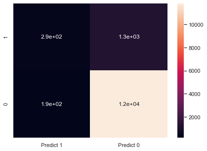

```python
cm=metrics.confusion_matrix(y_test, y_predict, labels=[1, 0])
print("Numbers from Confusion Matrix")
print(cm)
df_cm = pd.DataFrame(cm, index = [i for i in ["1","0"]],
                  columns = [i for i in ["Predict 1","Predict 0"]])
plt.figure(figsize = (7,5))
sns.heatmap(df_cm, annot=True)
print("")

#Confusion Matrix
print("Confusion Matrix")
def draw_cm( actual, predicted ):
    cm = confusion_matrix( actual, predicted)
    sns.heatmap(cm, annot=True,  fmt='.2f', xticklabels = [0,1] , yticklabels = [0,1] )
    plt.ylabel('Observed')
    plt.xlabel('Predicted')
    plt.show()
```

```python
from sklearn.metrics import confusion_matrix, recall_score, precision_score, f1_score, roc_auc_score,accuracy_score

print("Trainig accuracy",model.score(X_train,y_train))
print()
print("Testing accuracy",model.score(X_test, y_test))
print()
print("Recall:",recall_score(y_test,y_predict))
print()
print("Precision:",precision_score(y_test,y_predict))
print()
print("F1 Score:",f1_score(y_test,y_predict))
print()
print("Roc Auc Score:",roc_auc_score(y_test,y_predict))
```

```
Trainig accuracy 0.8909533289095333

Testing accuracy 0.8930256561486287

Recall: 0.18504190844616378

Precision: 0.6054852320675106

F1 Score: 0.2834567901234568

Roc Auc Score: 0.5847377193941466
```

```python
#Making dataframe for logistic regression metrics
data ={'Metrics':['Training Accuracy', 'Testing Accuracy', 'Recall', 'Precision', 'F1 Score', 'ROC AUC Score'], 'Logistic_Regression':[model.score(X_train,y_train), model.score(X_test, y_test), recall_score(y_test,y_predict), precision_score(y_test,y_predict), f1_score(y_test,y_predict), roc_auc_score(y_test,y_predict)]}
```

```python
dataframe1 = pd.DataFrame(data)
```

```python
dataframe1
```

|  | Metrics | Logistic_Regression |
| --- | --- | --- |
| 0 | Training Accuracy | 0.890953 |
| 1 | Testing Accuracy | 0.893026 |
| 2 | Recall | 0.185042 |
| 3 | Precision | 0.605485 |
| 4 | F1 Score | 0.283457 |
| 5 | ROC AUC Score | 0.584738 |

The logistic regression model may not be the best suited for this data. Training accuracy and testing accuracy are 90%, and very high. These high scores are due to the large number correctly predicted negatives (true negatives).

However, looking at the misclassified cases is more important in this model's evaluation. Recall for this logistic regression model is: 0.19, which is considered low. This is bad. Recall determine of all who subscribed to a term deposit in the past, how many did the model predict accurately. 1-Recall (0.81) explains the severity of false negatives. This is somewhat high and can be good for the bank even though it indicates a bad model. These cases are people who decided to invest into a term deposit even though the model did not predict them to. This allows the bank to get more money than expected from the model, and to invest in high profitable business ventures to maximize gain. The bank would benefit with a higher 1-Recall value but it also means that the model's predictions were not very good. 1264 cases are false negatives.

Since the number of false negatives is more than false positives, the bank would in the end gain, according to this model. However, because the model's recall and precision scores are not that great, we would need to question whether another model would be better suited for this data. The F1 Score is also low and is indicative of a not so great model.

The net gain for the bank, other than the true positive cases, is predicted to be: 1264-187= 1077 term deposit acounts.

```python
## Feature Importance or Coefficients
fi = pd.DataFrame()
fi['Col'] = X_train.columns
fi['Coeff'] = np.round(abs(model.coef_[0]),2)
fi.sort_values(by='Coeff',ascending=False)
```

|  | Col | Coeff |
| --- | --- | --- |
| 42 | poutcome_success | 1.45 |
| 35 | month_mar | 1.04 |
| 32 | month_jan | 1.02 |
| 27 | contact_unknown | 0.89 |
| 38 | month_oct | 0.75 |
| 37 | month_nov | 0.74 |
| 39 | month_sep | 0.72 |
| 29 | month_aug | 0.71 |
| 40 | poutcome_failure | 0.71 |
| 43 | poutcome_unknown | 0.65 |
| 33 | month_jul | 0.58 |
| 30 | month_dec | 0.56 |
| 49 | agerange_70-79 | 0.54 |
| 47 | agerange_50-59 | 0.47 |
| 2 | housing | 0.47 |
| 41 | poutcome_other | 0.46 |
| 46 | agerange_40-49 | 0.45 |
| 45 | agerange_30-39 | 0.41 |
| 25 | contact_cellular | 0.41 |
| 36 | month_may | 0.37 |
| 3 | loan | 0.35 |
| 31 | month_feb | 0.32 |
| 34 | month_jun | 0.31 |
| 8 | job_entrepreneur | 0.27 |
| 21 | education_primary | 0.27 |
| 19 | marital_married | 0.27 |
| 48 | agerange_60-69 | 0.26 |
| 50 | agerange_80-89 | 0.26 |
| 14 | job_student | 0.25 |
| 9 | job_housemaid | 0.24 |
| 16 | job_unemployed | 0.15 |
| 0 | default | 0.15 |
| 17 | job_unknown | 0.13 |
| 5 | campaign | 0.12 |
| 12 | job_self-employed | 0.12 |
| 44 | agerange_18-29 | 0.11 |
| 26 | contact_telephone | 0.10 |
| 22 | education_secondary | 0.10 |
| 11 | job_retired | 0.10 |
| 7 | job_blue-collar | 0.09 |
| 24 | education_unknown | 0.06 |
| 23 | education_tertiary | 0.06 |
| 20 | marital_single | 0.06 |
| 6 | job_admin. | 0.05 |
| 18 | marital_divorced | 0.04 |
| 15 | job_technician | 0.03 |
| 10 | job_management | 0.02 |
| 13 | job_services | 0.01 |
| 51 | agerange_90-99 | 0.01 |
| 28 | month_apr | 0.00 |
| 1 | balance | 0.00 |
| 4 | day | 0.00 |

When evaluating the features of importance, after the use of one hot encoding, it seems that poutcome_success (coefficient: 1.45) has the most influence on this model when making predictions. Month_march (1.04), month_jan (1.02), contact_unknown(0.89), month_october (0.75), also exert high influence on this model, as well. The components that exert the most influence are for the most part the poutcome variables, the month variables, and contact variables.

Variables with moderate impact include housing (0.47), loan(0.35), and different age categories like 70-79 (0.54)and 50-59 (0.47).

#### Decision Tree Model

```python
dTree = DecisionTreeClassifier(criterion = 'gini', random_state=1)
dTree.fit(X_train, y_train)
```

```
DecisionTreeClassifier(random_state=1)
```

```python
print(dTree.score(X_train, y_train))
print(dTree.score(X_test, y_test))
```

```
0.9994628242803425
0.8271158950162194
```

This shows the model overfit to the training data. So we must do pruning.

```python
#Pruning

dTreeR = DecisionTreeClassifier(criterion = 'gini', max_depth = 7, random_state=1)
dTreeR.fit(X_train, y_train)
print(dTreeR.score(X_train, y_train))
print(dTreeR.score(X_test, y_test))
```

```
0.8978734161215913
0.8936154526688292
```

The model fits well to the training data and the testing data. The scores are very close to one another.

```python
print (pd.DataFrame(dTreeR.feature_importances_, columns = ["Imp"], index = X_train.columns))
```

```
                          Imp
default              0.000000
balance              0.025421
housing              0.014305
loan                 0.001614
day                  0.057128
campaign             0.008056
job_admin.           0.005837
job_blue-collar      0.000000
job_entrepreneur     0.001912
job_housemaid        0.000000
job_management       0.000712
job_retired          0.001274
job_self-employed    0.001095
job_services         0.000000
job_student          0.001232
job_technician       0.004263
job_unemployed       0.000000
job_unknown          0.000000
marital_divorced     0.004436
marital_married      0.001687
marital_single       0.001183
education_primary    0.000411
education_secondary  0.001754
education_tertiary   0.001814
education_unknown    0.003636
contact_cellular     0.002094
contact_telephone    0.000000
contact_unknown      0.070196
month_apr            0.003303
month_aug            0.004610
month_dec            0.000000
month_feb            0.008061
month_jan            0.000000
month_jul            0.000000
month_jun            0.055266
month_mar            0.056887
month_may            0.008904
month_nov            0.002239
month_oct            0.058660
month_sep            0.050280
poutcome_failure     0.001273
poutcome_other       0.000000
poutcome_success     0.501241
poutcome_unknown     0.001162
agerange_18-29       0.000000
agerange_30-39       0.000000
agerange_40-49       0.006180
agerange_50-59       0.002169
agerange_60-69       0.029708
agerange_70-79       0.000000
agerange_80-89       0.000000
agerange_90-99       0.000000
```

Like what was observed in the logistic regression model, poutcome_success (0.5) had the highest impact on the model. Contact_unknown was the second most contributive variable to this model. Among the months, Month_march, month_june, month_september and month_october played a moderate role in creating this prediction model. Oddly, month_jan did not seem as important in this model as it did in the logistic regression model. There are other less contributive components that may make a smaller impact.

```
0.8936154526688292
```

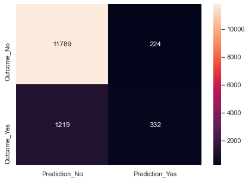

```python
print(dTreeR.score(X_test , y_test))
y_predict = dTreeR.predict(X_test)

cm=metrics.confusion_matrix(y_test, y_predict, labels=[0, 1])

df_cm = pd.DataFrame(cm, index = [i for i in ["Outcome_No","Outcome_Yes"]],
                  columns = [i for i in ["Prediction_No","Prediction_Yes"]])
plt.figure(figsize = (7,5))
sns.heatmap(df_cm, annot=True ,fmt='g')
```

```python
print("Trainig accuracy",model.score(X_train,y_train))
print()
print("Testing accuracy",model.score(X_test, y_test))
print()
print("Recall:",recall_score(y_test,y_predict))
print()
print("Precision:",precision_score(y_test,y_predict))
print()
print("F1 Score:",f1_score(y_test,y_predict))
print()
print("Roc Auc Score:",roc_auc_score(y_test,y_predict))
```

```
Trainig accuracy 0.8909533289095333

Testing accuracy 0.8930256561486287

Recall: 0.21405544809800128

Precision: 0.5971223021582733

F1 Score: 0.31514000949216897

Roc Auc Score: 0.5977044908849284
```

```python
#Making dataframe for Decision Tree metrics
data ={'Metrics':['Training Accuracy', 'Testing Accuracy', 'Recall', 'Precision', 'F1 Score', 'ROC AUC Score'], 'Decision_Tree':[model.score(X_train,y_train), model.score(X_test, y_test), recall_score(y_test,y_predict), precision_score(y_test,y_predict), f1_score(y_test,y_predict), roc_auc_score(y_test,y_predict)]}
```

```python
dataframe2 = pd.DataFrame(data)
```

```python
dataframe2
```

[output not shown]

From these results, you could tell that this decision tree model is performing better than the logistic regression model. You can instantly tell from looking at the F1 score and the ROC score are better than the logistic regression model. The recall is now 0.214, which shows an increase. Precision stayed about the same at 0.6. The number of true positives has increased to 332, suggesting improvement from the previos model. 1219 individuals are false negatives. 224 cases are false positives.

Again, the bank would gain because the number of false negatives is more than false positives but the model is still not performing adequately because the recall is still low. The precision value is adequate.

The net gain for the bank, other than the true positive cases, is predicted to be: 1219-224= 995 term deposit acounts.

```python
#Bagging
from sklearn.ensemble import BaggingClassifier

bgcl = BaggingClassifier(base_estimator=dTree, n_estimators=50,random_state=1)
#bgcl = BaggingClassifier(n_estimators=50,random_state=1)

bgcl = bgcl.fit(X_train, y_train)
```

```
0.890002948982601
```

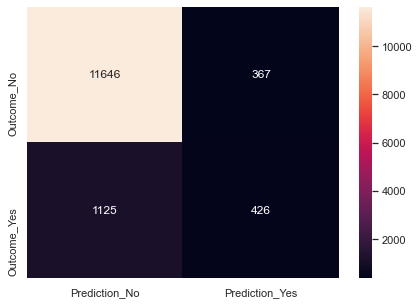

```python
y_predict = bgcl.predict(X_test)

print(bgcl.score(X_test , y_test))

cm=metrics.confusion_matrix(y_test, y_predict,labels=[0, 1])

df_cm = pd.DataFrame(cm, index = [i for i in ["Outcome_No","Outcome_Yes"]],
                  columns = [i for i in ["Prediction_No","Prediction_Yes"]])
plt.figure(figsize = (7,5))
sns.heatmap(df_cm, annot=True ,fmt='g')
```

```python
print("Trainig accuracy",model.score(X_train,y_train))
print()
print("Testing accuracy",model.score(X_test, y_test))
print()
print("Recall:",recall_score(y_test,y_predict))
print()
print("Precision:",precision_score(y_test,y_predict))
print()
print("F1 Score:",f1_score(y_test,y_predict))
print()
print("Roc Auc Score:",roc_auc_score(y_test,y_predict))
```

```
Trainig accuracy 0.8909533289095333

Testing accuracy 0.8930256561486287

Recall: 0.2746615087040619

Precision: 0.5372005044136192

F1 Score: 0.36348122866894206

Roc Auc Score: 0.6220556357305376
```

```python
#Making dataframe for Bagging metrics
data ={'Metrics':['Training Accuracy', 'Testing Accuracy', 'Recall', 'Precision', 'F1 Score', 'ROC AUC Score'], 'Bagging':[model.score(X_train,y_train), model.score(X_test, y_test), recall_score(y_test,y_predict), precision_score(y_test,y_predict), f1_score(y_test,y_predict), roc_auc_score(y_test,y_predict)]}
```

```python
dataframe3 = pd.DataFrame(data)
```

```python
dataframe3
```

[output not shown]

For the bagging model, the recall (0.27) has improved but the precision (0.53) values have gone down. The question that we need to ask is whether a recall score or precision score is more important. Like the other models, the accuracy is high due to the large true negatives value. There is a net gain, despite the amount of misclassification by the model; the false negative value is more than the false positives values. The net gain of customers, other than the true positive cases, that will participate in term deposits is: 1125-367 = 758 customers (term deposit accounts).

```python
from sklearn.ensemble import AdaBoostClassifier
abcl = AdaBoostClassifier(n_estimators=10, random_state=1)
#abcl = AdaBoostClassifier( n_estimators=50,random_state=1)
abcl = abcl.fit(X_train, y_train)
```

```
0.8951636685343557
```

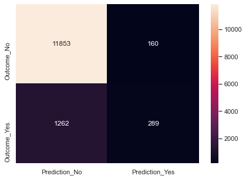

```python
y_predict = abcl.predict(X_test)
print(abcl.score(X_test , y_test))

cm=metrics.confusion_matrix(y_test, y_predict,labels=[0, 1])

df_cm = pd.DataFrame(cm, index = [i for i in ["Outcome_No","Outcome_Yes"]],
                  columns = [i for i in ["Prediction_No","Prediction_Yes"]])
plt.figure(figsize = (7,5))
sns.heatmap(df_cm, annot=True ,fmt='g')
```

```python
print("Trainig accuracy",model.score(X_train,y_train))
print()
print("Testing accuracy",model.score(X_test, y_test))
print()
print("Recall:",recall_score(y_test,y_predict))
print()
print("Precision:",precision_score(y_test,y_predict))
print()
print("F1 Score:",f1_score(y_test,y_predict))
print()
print("Roc Auc Score:",roc_auc_score(y_test,y_predict))
```

```
Trainig accuracy 0.8909533289095333

Testing accuracy 0.8930256561486287

Recall: 0.18633139909735655

Precision: 0.643652561247216

F1 Score: 0.28900000000000003

Roc Auc Score: 0.5865062472886267
```

```python
#Making dataframe for AdaBoost metrics
data ={'Metrics':['Training Accuracy', 'Testing Accuracy', 'Recall', 'Precision', 'F1 Score', 'ROC AUC Score'], 'AdaBoost':[model.score(X_train,y_train), model.score(X_test, y_test), recall_score(y_test,y_predict), precision_score(y_test,y_predict), f1_score(y_test,y_predict), roc_auc_score(y_test,y_predict)]}
```

```python
dataframe4 = pd.DataFrame(data)
```

```python
dataframe4
```

[output not shown]

The recall score is 0.19, which is lower than the decision tree model and the bagging model. The precision score is 0.64 for the Adaboosting model, which is higher than all the previous models.

The net gain for the bank, other than the true positive cases, is predicted to be: 1262-160= 1102 term deposit acounts.

```python
from sklearn.ensemble import GradientBoostingClassifier
gbcl = GradientBoostingClassifier(n_estimators = 50,random_state=1)
gbcl = gbcl.fit(X_train, y_train)
```

```
0.8948687702742554
```

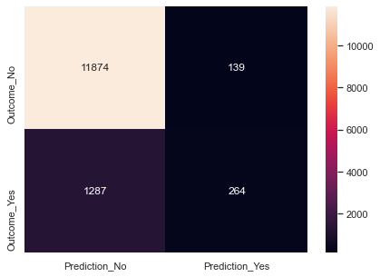

```python
y_predict = gbcl.predict(X_test)
print(gbcl.score(X_test, y_test))
cm=metrics.confusion_matrix(y_test, y_predict,labels=[0, 1])

df_cm = pd.DataFrame(cm, index = [i for i in ["Outcome_No","Outcome_Yes"]],
                  columns = [i for i in ["Prediction_No","Prediction_Yes"]])
plt.figure(figsize = (7,5))
sns.heatmap(df_cm, annot=True ,fmt='g')
```

```python
#Metrics
print("Trainig accuracy",model.score(X_train,y_train))
print()
print("Testing accuracy",model.score(X_test, y_test))
print()
print("Recall:",recall_score(y_test,y_predict))
print()
print("Precision:",precision_score(y_test,y_predict))
print()
print("F1 Score:",f1_score(y_test,y_predict))
print()
print("Roc Auc Score:",roc_auc_score(y_test,y_predict))
```

```
Trainig accuracy 0.8909533289095333

Testing accuracy 0.8930256561486287

Recall: 0.1702127659574468

Precision: 0.6550868486352357

F1 Score: 0.27021494370522003

Roc Auc Score: 0.5793209838278035
```

```python
#Making dataframe for GradientBoost metrics
data ={'Metrics':['Training Accuracy', 'Testing Accuracy', 'Recall', 'Precision', 'F1 Score', 'ROC AUC Score'], 'GradientBoost':[model.score(X_train,y_train), model.score(X_test, y_test), recall_score(y_test,y_predict), precision_score(y_test,y_predict), f1_score(y_test,y_predict), roc_auc_score(y_test,y_predict)]}
```

```python
dataframe5 = pd.DataFrame(data)
```

```python
dataframe5
```

[output not shown]

The recall score is 0.17, which is lower than all of the other models. The precision score is 0.66 for the Gradientboosting model, which is higher than all the previous models.

The net gain for the bank, other than the true positive cases, is predicted to be: 1287-139= 1148 term deposit acounts.

### EXTRA

```python
#Random forest model:

from sklearn.ensemble import RandomForestClassifier
rfcl = RandomForestClassifier(n_estimators = 50, random_state=1,max_features=12)
rfcl = rfcl.fit(X_train, y_train)
```

```
0.891108817457977
```

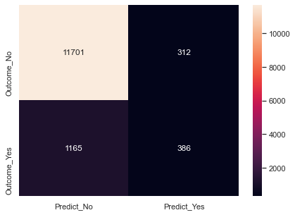

```python
#Confusion Matrix
y_predict = rfcl.predict(X_test)
print(rfcl.score(X_test, y_test))
cm=metrics.confusion_matrix(y_test, y_predict,labels=[0, 1])

df_cm = pd.DataFrame(cm, index = [i for i in ["Outcome_No","Outcome_Yes"]],
                  columns = [i for i in ["Predict_No","Predict_Yes"]])
plt.figure(figsize = (7,5))
sns.heatmap(df_cm, annot=True ,fmt='g')
```

```python
#Metrics
print("Trainig accuracy",model.score(X_train,y_train))
print()
print("Testing accuracy",model.score(X_test, y_test))
print()
print("Recall:",recall_score(y_test,y_predict))
print()
print("Precision:",precision_score(y_test,y_predict))
print()
print("F1 Score:",f1_score(y_test,y_predict))
print()
print("Roc Auc Score:",roc_auc_score(y_test,y_predict))
```

```
Trainig accuracy 0.8909533289095333

Testing accuracy 0.8930256561486287

Recall: 0.2488716956802063

Precision: 0.5530085959885387

F1 Score: 0.34326367274344155

Roc Auc Score: 0.6114499159330026
```

The recall score is 0.25. The precision score is 0.55 for the Random Forest, which is not as high as GradientBoost.

The net gain for the bank, other than the true positive cases, is predicted to be: 1165-312= 853 term deposit acounts.

```python
#Making dataframe out of the random forest metrics
data ={'Metrics':['Training Accuracy', 'Testing Accuracy', 'Recall', 'Precision', 'F1 Score', 'ROC AUC Score'], 'Random_Forest':[model.score(X_train,y_train), model.score(X_test, y_test), recall_score(y_test,y_predict), precision_score(y_test,y_predict), f1_score(y_test,y_predict), roc_auc_score(y_test,y_predict)]}
```

```python
dataframe6 = pd.DataFrame(data)
```

```python
dataframe6
```

|  | Metrics | Random_Forest |
| --- | --- | --- |
| 0 | Training Accuracy | 0.890953 |
| 1 | Testing Accuracy | 0.893026 |
| 2 | Recall | 0.248872 |
| 3 | Precision | 0.553009 |
| 4 | F1 Score | 0.343264 |
| 5 | ROC AUC Score | 0.611450 |

```python
# 3. Merge all dataframes together to make a large dataframe with all metrics for all algorithms

Metrics_Dataframe = pd.merge(dataframe1,dataframe2,how='outer',on='Metrics')
Metrics_Dataframe = pd.merge(Metrics_Dataframe, dataframe3,how='outer',on='Metrics')
Metrics_Dataframe = pd.merge(Metrics_Dataframe, dataframe4,how='outer',on='Metrics')
Metrics_Dataframe = pd.merge(Metrics_Dataframe, dataframe5,how='outer',on='Metrics')
Metrics_Dataframe = pd.merge(Metrics_Dataframe, dataframe6,how='outer',on='Metrics')
```

```python
Metrics_Dataframe
```

|  | Metrics | Logistic_Regression | Decision_Tree | Bagging | AdaBoost | GradientBoost | Random_Forest |
| --- | --- | --- | --- | --- | --- | --- | --- |
| 0 | Training Accuracy | 0.890953 | 0.890953 | 0.890953 | 0.890953 | 0.890953 | 0.890953 |
| 1 | Testing Accuracy | 0.893026 | 0.893026 | 0.893026 | 0.893026 | 0.893026 | 0.893026 |
| 2 | Recall | 0.185042 | 0.214055 | 0.274662 | 0.186331 | 0.170213 | 0.248872 |
| 3 | Precision | 0.605485 | 0.597122 | 0.537201 | 0.643653 | 0.655087 | 0.553009 |
| 4 | F1 Score | 0.283457 | 0.315140 | 0.363481 | 0.289000 | 0.270215 | 0.343264 |
| 5 | ROC AUC Score | 0.584738 | 0.597704 | 0.622056 | 0.586506 | 0.579321 | 0.611450 |

All the models have about the same training and testing accuracy scores.

It seems that of all the models, bagging has the best recall score but GradientBoost has the best precision.

Bagging has the highest ROC area under the curve score and may be the best model overall.

However, the one model that generates the most gain from the misclassification errors is: Gradientboost. It has highest Precision and the lowest false positives of all the models.

In other words, for the bank to actually make a profit, you would want a model with more false negative values (Customers that were predicted to not subscribe to a term deposit but actually ended up doing it) and less false positive values (Customers that were predicted to subscribe for a term deposit but ended up not participating.) This, however, may not be the best model that makes the best predictions.

Bagging seems to be the best model with the highest ROC score and the highest F1 Score that may make the best predictions, but the bank earns more with a model like Gradientboost because it has the lowest false positives and the highest precision.